# Reproduceible Research

Yinphan Tsang

Sunday, September 14, 2014

### Loading and preprocessing the data

1. load the data

```r
activity.monitoring<-read.csv("activity.csv")
```

2. Process/transform the data (if necessary) into a format suitable for your analysis

```r
library(xts)
#tranform to date format
activity.monitoring$date<-as.Date(levels(activity.monitoring$date)[activity.monitoring$date])
rawdata.xts<-xts(activity.monitoring$steps,activity.monitoring$date)
Dtotal<-apply.daily(rawdata.xts,sum, na.rm=TRUE)
```

### What is mean total number of steps taken per day?

For this part of the assignment, you can ignore the missing values in the dataset.

1. Make a histogram of the total number of steps taken each day

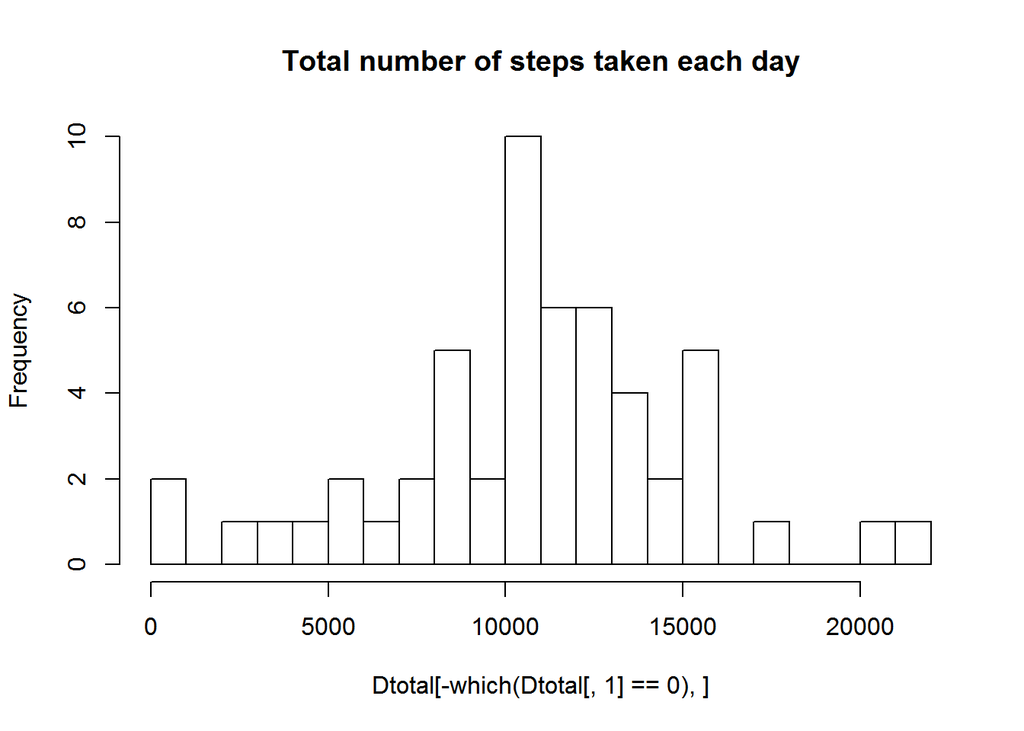

```r
hist(Dtotal[-which(Dtotal[,1]==0),],30, main="Total number of steps taken each day")
```

```r
DMean<-mean(apply.daily(rawdata.xts,mean,na.rm=TRUE), na.rm=TRUE)
DMedian<-mean(apply.daily(rawdata.xts,median,na.rm=TRUE), na.rm=TRUE)
```

### What is the average daily activity pattern?

1. Make a time series plot (i.e. type = “l”) of the 5-minute interval (x-axis) and the average number of steps taken, averaged across all days (y-axis)

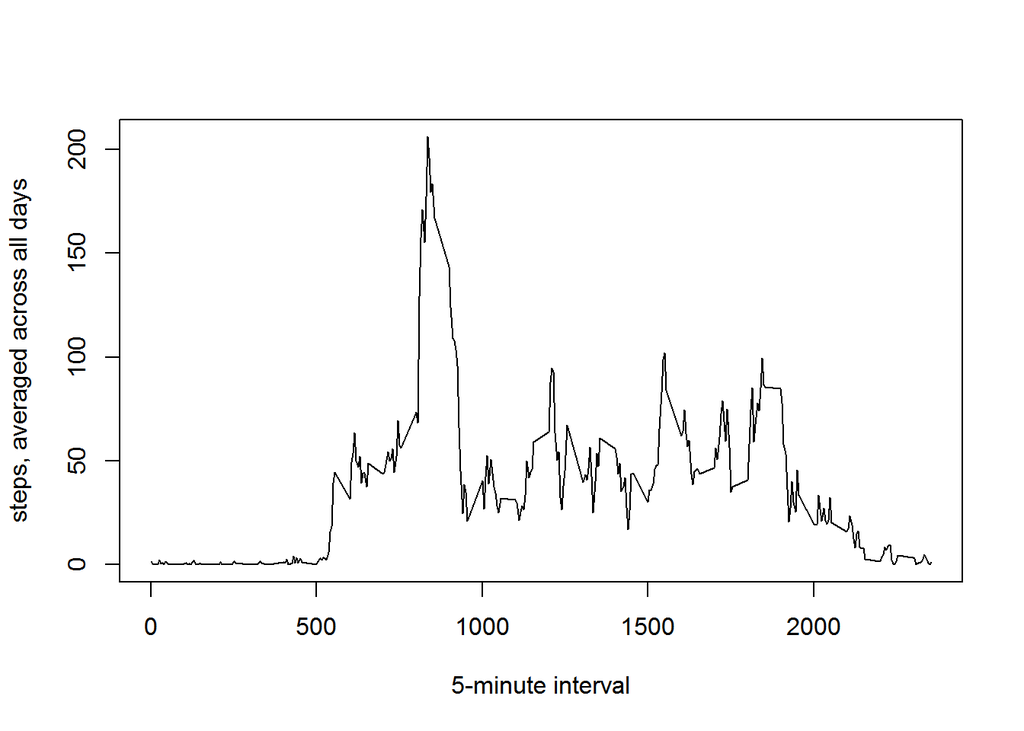

```r
timeseries<-c()
for(i in unique(activity.monitoring$interval)){
  i_interval<-which(activity.monitoring$interval==i)
  avg<-mean(activity.monitoring$steps[i_interval],na.rm=TRUE)
  intervalaverage<-data.frame(interval=i,average=avg)
  timeseries<-rbind(timeseries,intervalaverage)
}
plot(timeseries,type="l",xlab="5-minute interval",ylab="steps, averaged across all days")
```

2. Which 5-minute interval, on average across all the days in the dataset, contains the maximum number of steps?

```r
i_interval<-which(timeseries$average==max(timeseries$average))
maxinterval<-timeseries$interval[i_interval]
maxaverage<-timeseries$average[i_interval]
```

Answer: The 835 (5-minute interval) has the maximum number 206.1698 steps.

### Imputing missing values

Note that there are a number of days/intervals where there are missing values (coded as NA). The presence of missing days may introduce bias into some calculations or summaries of the data.

1. Calculate and report the total number of missing values in the dataset (i.e. the total number of rows with NAs)

```r
totalna<-length(which(is.na(activity.monitoring$steps)))
```

Answer: There are a total number of 2304 rows with NAs.

2. Devise a strategy for filling in all of the missing values in the dataset. The strategy does not need to be sophisticated. For example, you could use the mean/median for that day, or the mean for that 5-minute interval, etc.
3. Create a new dataset that is equal to the original dataset but with the missing data filled in.

```r
update.activity.monitoring<-activity.monitoring
for(i in unique(activity.monitoring$interval)){
   i_interval<-which(activity.monitoring$interval==i)
   i_interval.na<-which(is.na(activity.monitoring$steps[i_interval]))
   i_timeseries.interval<-which(timeseries$interval==i)
   update.activity.monitoring$steps[i_interval[i_interval.na]]<-timeseries$average[i_timeseries.interval]
}
```

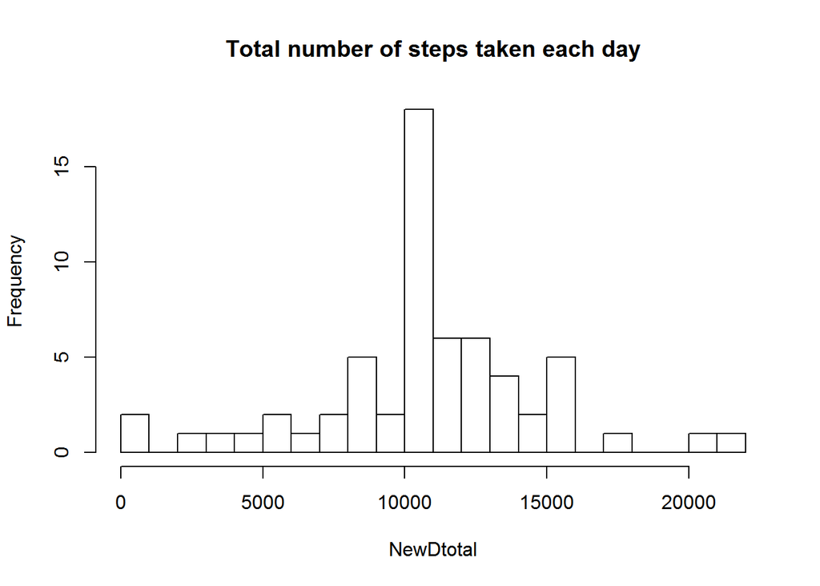

```r
library(xts)
#tranform to date format
newrawdata.xts<-xts(update.activity.monitoring$steps,update.activity.monitoring$date)
NewDtotal<-apply.daily(newrawdata.xts,sum, na.rm=TRUE)
hist(NewDtotal,30, main="Total number of steps taken each day")
```

```r
NewDMean<-mean(apply.daily(newrawdata.xts,mean,na.rm=TRUE), na.rm=TRUE)
NewDMedian<-mean(apply.daily(newrawdata.xts,median,na.rm=TRUE), na.rm=TRUE)
```

### Are there differences in activity patterns between weekdays and weekends?

```r
days<-weekdays(activity.monitoring$date)
weekend<-days
i_weekend<-which(days=="Saturday"|days=="Sunday")
i_weekday<-setdiff(c(1:length(days)),i_weekend)
weekend[i_weekend]<-"weekend"
weekend[i_weekday]<-"weekday"
weekend<-as.factor(weekend)
activity.monitoring<-cbind(activity.monitoring,weekend)
```

2. Make a panel plot containing a time series plot (i.e. type = “l”) of the 5-minute interval (x-axis) and the average number of steps taken, averaged across all weekday days or weekend days (y-axis). The plot should look something like the following, which was creating using simulated data:

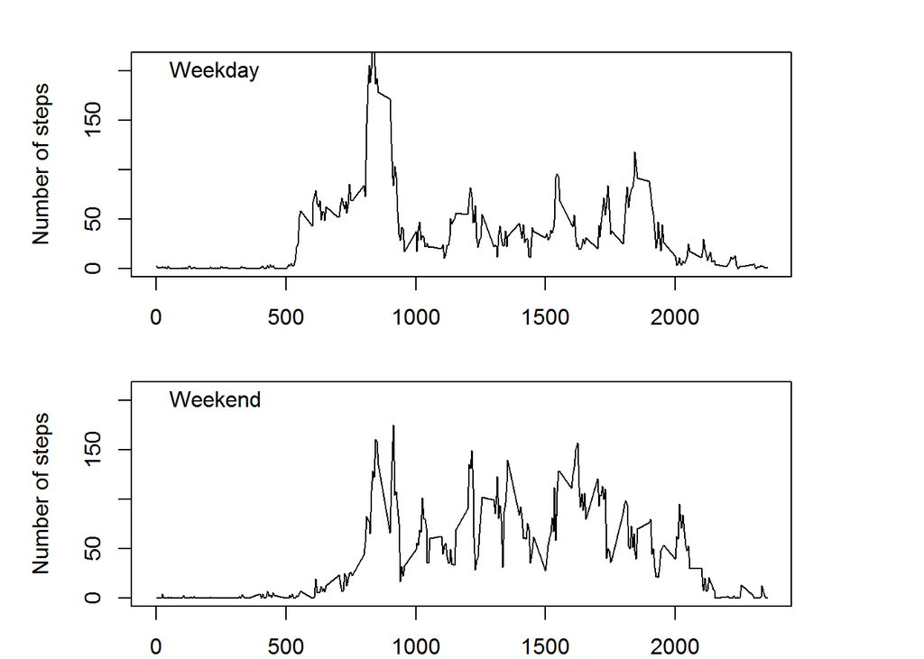

```r
timeseries_weekday<-c()
timeseries_weekend<-c()
for(i in unique(activity.monitoring$interval)){
  i_interval<-which(activity.monitoring$interval==i)
  #weekday
  i_interval_weekday<-which(activity.monitoring$weekend[i_interval]=="weekday")
  avg<-mean(activity.monitoring$steps[i_interval[i_interval_weekday]],na.rm=TRUE)
  intervalaverage<-data.frame(interval=i,average=avg)
  timeseries_weekday<-rbind(timeseries_weekday,intervalaverage)
  #weekend
  i_interval_weekend<-which(activity.monitoring$weekend[i_interval]=="weekend")
  avg<-mean(activity.monitoring$steps[i_interval[i_interval_weekend]],na.rm=TRUE)
  intervalaverage<-data.frame(interval=i,average=avg)
  timeseries_weekend<-rbind(timeseries_weekend,intervalaverage)
}
par(mfrow=c(2,1), pin=c(5,1.7))
plot(timeseries_weekday,type="l",xlab="5-minute interval",ylab="Number of steps",ylim=c(0,210))
text(0,200,"Weekday",pos=4)
plot(timeseries_weekend,type="l",xlab="5-minute interval",ylab="Number of steps",ylim=c(0,210))
text(0,200,"Weekend",pos=4)
```